# Case Study 01 About Beers

Eng Kim Wong

7/2/2017

## Introduction

This is an analysis about US craft beers and Breweries. There are 2 datasets : Beers.csv and Breweries.csv. They are merged to facilitate further analysis. We look at the total number of breweries in each state and compute the median alcohol content and internatial bitterness for each state. A bar chart is plotted to graphically present the result. I further present the state has the maximum alcoholic beer and state that has the most bitter beer. Finally the analysis end with the summary statistic for ABV (Alcohol by Volume) and the relationship between ABV and IBU (International bitterness unit) on scatter plot.

##### Preparing beers.csv and breweries.csv data files for analysis:

```r
beers <- read.csv("Beers.csv")
breweries <- read.csv("Breweries.csv")
```

#### How many breweries are present in each state?

```r
library(plyr) # import plyr and ggplot2 library
library(ggplot2)
brewery.count.by.state <- count(breweries$State)  # obtain count of breweries in each state
colnames(brewery.count.by.state) <- c("States", "Count") # changing column names
```

##### *Breweries in each state*

```r
print(brewery.count.by.state)
```

```
##    States Count
## 1      AK     7
## 2      AL     3
## 3      AR     2
## 4      AZ    11
## 5      CA    39
## 6      CO    47
## 7      CT     8
## 8      DC     1
## 9      DE     2
## 10     FL    15
## 11     GA     7
## 12     HI     4
## 13     IA     5
## 14     ID     5
```

[output cut: 37 more lines]

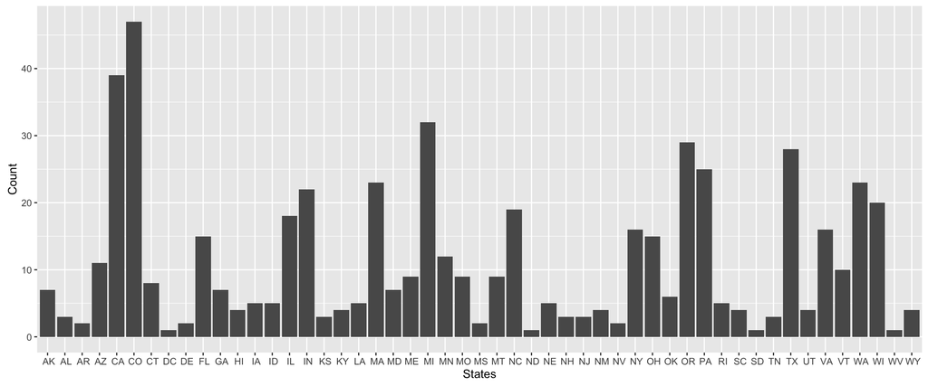

```r
p1 <- ggplot(data = brewery.count.by.state, aes(x=States, y=Count)) + geom_bar(stat="identity") # bar plot
p1
```

#### Merge the two data sets:

```r
# change breweries$brew_id name to be Brewery_id so we can merge on common id
colnames(breweries)[1] <- "Brewery_id"
colnames(breweries)[2] <- "Brewery_name"
colnames(beers)[1] <- "Beer_name"
```

```r
beersnbreweries <- merge.data.frame(beers, breweries, by="Brewery_id")
```

###### First 6 observations

```
##   Brewery_id     Beer_name Beer_ID   ABV IBU
## 1          1  Get Together    2692 0.045  50
## 2          1 Maggie's Leap    2691 0.049  26
## 3          1    Wall's End    2690 0.048  19
## 4          1       Pumpion    2689 0.060  38
## 5          1    Stronghold    2688 0.060  25
## 6          1   Parapet ESB    2687 0.056  47
##                                 Style Ounces       Brewery_name
## 1                        American IPA     16 NorthGate Brewing
## 2                  Milk / Sweet Stout     16 NorthGate Brewing
## 3                   English Brown Ale     16 NorthGate Brewing
## 4                         Pumpkin Ale     16 NorthGate Brewing
## 5                     American Porter     16 NorthGate Brewing
## 6 Extra Special / Strong Bitter (ESB)     16 NorthGate Brewing
##          City State
## 1 Minneapolis    MN
## 2 Minneapolis    MN
## 3 Minneapolis    MN
## 4 Minneapolis    MN
## 5 Minneapolis    MN
## 6 Minneapolis    MN
```

###### Last 6 observations

```
##      Brewery_id                 Beer_name Beer_ID   ABV IBU
## 2405        556             Pilsner Ukiah      98 0.055  NA
## 2406        557  Heinnieweisse Weissebier      52 0.049  NA
## 2407        557           Snapperhead IPA      51 0.068  NA
## 2408        557         Moo Thunder Stout      50 0.049  NA
## 2409        557         Porkslap Pale Ale      49 0.043  NA
## 2410        558 Urban Wilderness Pale Ale      30 0.049  NA
##                        Style Ounces                  Brewery_name
## 2405         German Pilsener     12         Ukiah Brewing Company
## 2406              Hefeweizen     12       Butternuts Beer and Ale
## 2407            American IPA     12       Butternuts Beer and Ale
## 2408      Milk / Sweet Stout     12       Butternuts Beer and Ale
## 2409 American Pale Ale (APA)     12       Butternuts Beer and Ale
## 2410        English Pale Ale     12 Sleeping Lady Brewing Company
##               City State
## 2405         Ukiah    CA
## 2406 Garrattsville    NY
## 2407 Garrattsville    NY
## 2408 Garrattsville    NY
## 2409 Garrattsville    NY
## 2410     Anchorage    AK
```

#### Number of invalid entries in each column:

```r
col.has.na <- sapply(beersnbreweries, function(y) sum(is.na(y)) ) # Obtain column that has na
```

##### *ABV column has 62 ‘na’ and IBU has 1005*

```r
col.has.na[ c(4,5)] # only ABV and IBU has 'na'
```

```
##  ABV  IBU
##   62 1005
```

#### Median of ABV (Alcohol by Volume) and IBU (International Bitterness Unit) by states:

###### ABV:

```r
# use deplyr pipe, remove 'na' when computing median
median.ABV.by.state <- beersnbreweries %>% group_by(State) %>% summarise(Median=median(ABV, na.rm=TRUE))
```

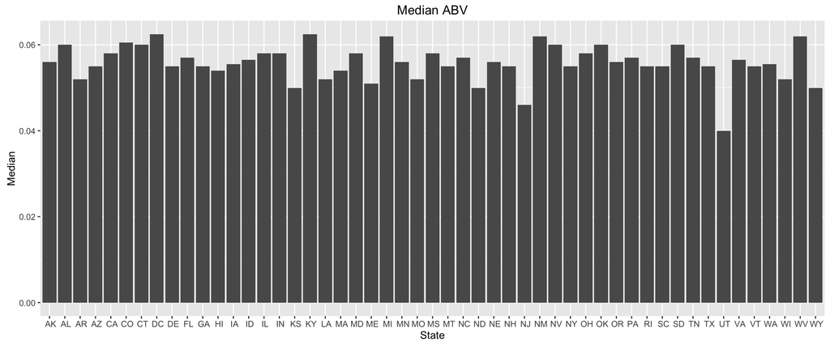

```r
# plotting median.ABV.by.state
p.median.ABV.by.state <- ggplot(data = median.ABV.by.state, aes(x=State, y=Median)) + geom_bar(stat="identity") + ggtitle("Median ABV")
p.median.ABV.by.state
```

###### IBU:

```r
median.IBU.by.state <- beersnbreweries %>% group_by(State) %>% summarise(Median=median(IBU, na.rm=TRUE))
```

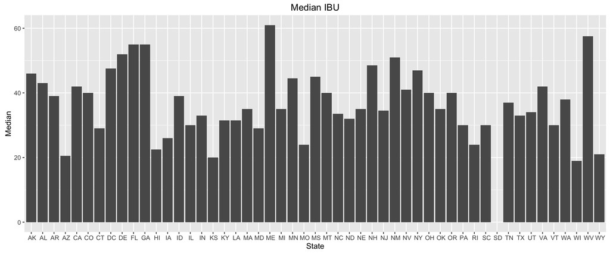

```r
# plotting median.IBU.by.state
p.median.IBU.by.state <- ggplot(data = median.IBU.by.state, aes(x=State, y=Median)) + geom_bar(stat="identity") + ggtitle("Median IBU")
p.median.IBU.by.state
```

###### *State SD has no valid entries for IBU!*

#### Which state has the maximum alcoholic beer? Which state has the most bitter beer?

###### Maximum alcoholic beer: **max ABV is in state CO, with value of 0.128**

```r
max.ABV.by.state <- beersnbreweries %>% group_by(State) %>% summarise(Max=max(ABV, na.rm=TRUE))
arrange(max.ABV.by.state, desc(Max))
```

```
## Source: local data frame [51 x 2]
##
##     State   Max
##    (fctr) (dbl)
## 1      CO 0.128
## 2      KY 0.125
## 3      IN 0.120
## 4      NY 0.100
## 5      CA 0.099
## 6      ID 0.099
## 7      MA 0.099
## 8      ME 0.099
## 9      MI 0.099
## 10     MN 0.099
## ..    ...   ...
```

###### Most bitter beer: **max IBU is in state OR, with value of 138**

```r
max.IBU.by.state <- beersnbreweries %>% group_by(State) %>% summarise(Max=max(IBU, na.rm=TRUE))
arrange(max.IBU.by.state, desc(Max))
```

```
## Source: local data frame [51 x 2]
##
##     State   Max
##    (fctr) (int)
## 1      OR   138
## 2      VA   135
## 3      MA   130
## 4      OH   126
## 5      MN   120
## 6      VT   120
## 7      TX   118
## 8      CA   115
## 9      DC   115
## 10     IN   115
## ..    ...   ...
```

#### Summary statistics for ABV (Alcohol by volume) variable

```r
beersnbreweries.abv <- beersnbreweries[,c(4)]
summary(beersnbreweries.abv)
```

```
##    Min. 1st Qu.  Median    Mean 3rd Qu.    Max.    NA's
## 0.00100 0.05000 0.05600 0.05977 0.06700 0.12800      62
```

#### Is there a relationship between the bitterness of the beer and its alcoholic content?

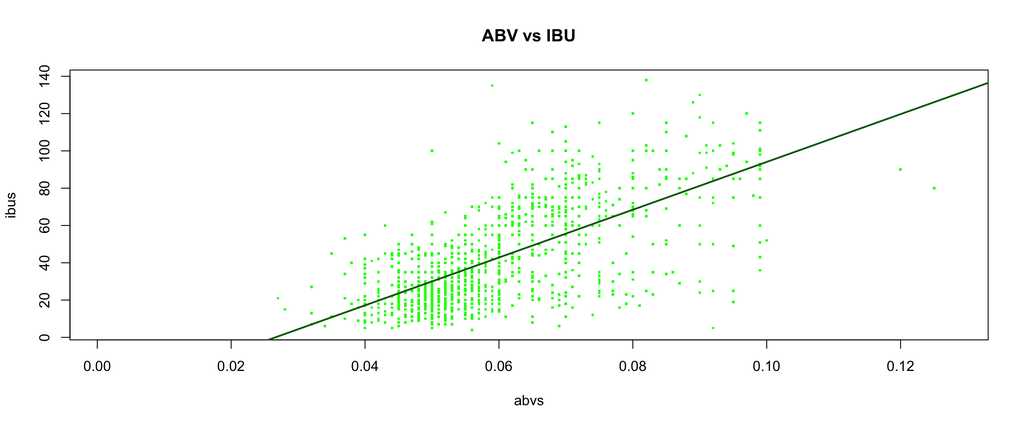

```r
abvs <- beersnbreweries.abv # a vector containing all abv
ibus <- beersnbreweries[,c(5)] # a vector containing all ibu
p.abv.vs.ibu <- plot(abvs, ibus, pch=".", cex=3, col="green", main = "ABV vs IBU") # pch is point shape, in this case a period character
abline(lm(ibus~abvs), col="darkgreen", lwd=2) # least squares regression, lwd is thickness of line
```

##### The scatter plot exhibits a positive correlation.

##### The more alcoholic content a beers has the higher the IBU value, that is the bitter the beer is.